# Chow’s Test

Benjamin Moran

2017-11-17

One of the goals of my project is to try and identify changes in the structure of the various flutracking time series (initially the % of unvaccinated respondents reporting ILI symptoms). There are two reasons for this that inspire two separate lines of inquiry: does the structure change from year to year; and does the structure change within each year?

Here we will be using Chow’s test to test for structural breaks in the flutracking data. Specifically, we’ll be testing the % of unvaccinated respondents reporting influenza-like illness (ILI) symptoms using the `strucchange` package in `R`. Firstly, let’s plot the %ILI Unvaccinated time series.

## Unvaccinated Repsondents Data

[figure not shown]

Now I’ll use the strucchange package to test for breaks. To test for breaks we fit a basic linear model: `lm(ILIts ~ 1)` where `ILIts` is the time series plotted abouve.

```
##
## Call:
## lm(formula = ILIts ~ 1)
##
## Residuals:
##      Min       1Q   Median       3Q      Max
## -1.90054 -0.70054 -0.00054  0.59946  1.99946
##
## Coefficients:
##             Estimate Std. Error t value Pr(>|t|)
## (Intercept)  3.00054    0.06487   46.26   <2e-16 ***
## ---
## Signif. codes:  0 '***' 0.001 '**' 0.01 '*' 0.05 '.' 0.1 ' ' 1
##
## Residual standard error: 0.8823 on 184 degrees of freedom
```

[figure not shown]

```
##
##   Optimal (m+1)-segment partition:
##
## Call:
## breakpoints.formula(formula = ILIts ~ 1, h = 0.1)
##
## Breakpoints at observation number:
##
## m = 1                      131
## m = 2         53           132
## m = 3         55    87     131
## m = 4      37 55    87     131
## m = 5      37 55 73    113 131
## m = 6      37 55 73    113 131     167
## m = 7      37 55 73 91 113 131     167
## m = 8   19 37 55 73 91 113 131     167
## m = 9   19 37 55 73 91 113 131 149 167
##
## Corresponding to breakdates:
##
## m = 1                      131
## m = 2         53           132
## m = 3         55    87     131
## m = 4      37 55    87     131
## m = 5      37 55 73    113 131
## m = 6      37 55 73    113 131     167
## m = 7      37 55 73 91 113 131     167
## m = 8   19 37 55 73 91 113 131     167
## m = 9   19 37 55 73 91 113 131 149 167
##
## Fit:
##
## m   0      1      2      3      4      5      6      7      8      9
## RSS 143.23 113.30 105.49  95.54  88.78  85.16  81.99  81.51  81.25  81.11
## BIC 488.11 455.18 452.40 444.51 441.38 444.13 447.55 456.91 466.76 476.87
```

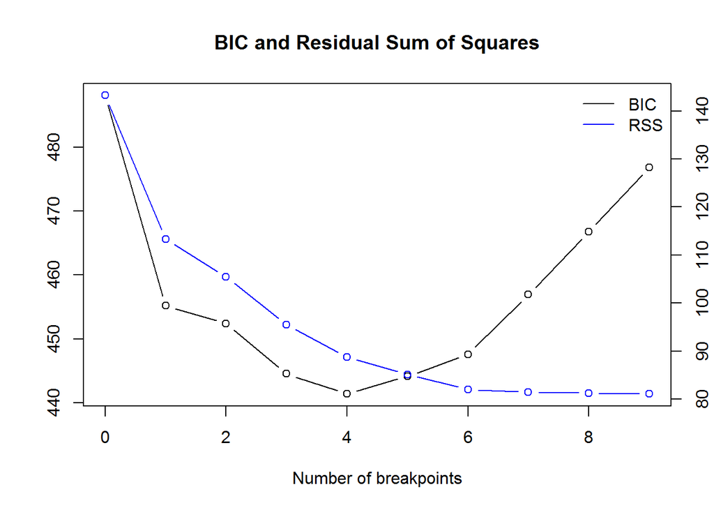

So the breakpoints function suggests that there are 4 (min. BIC).

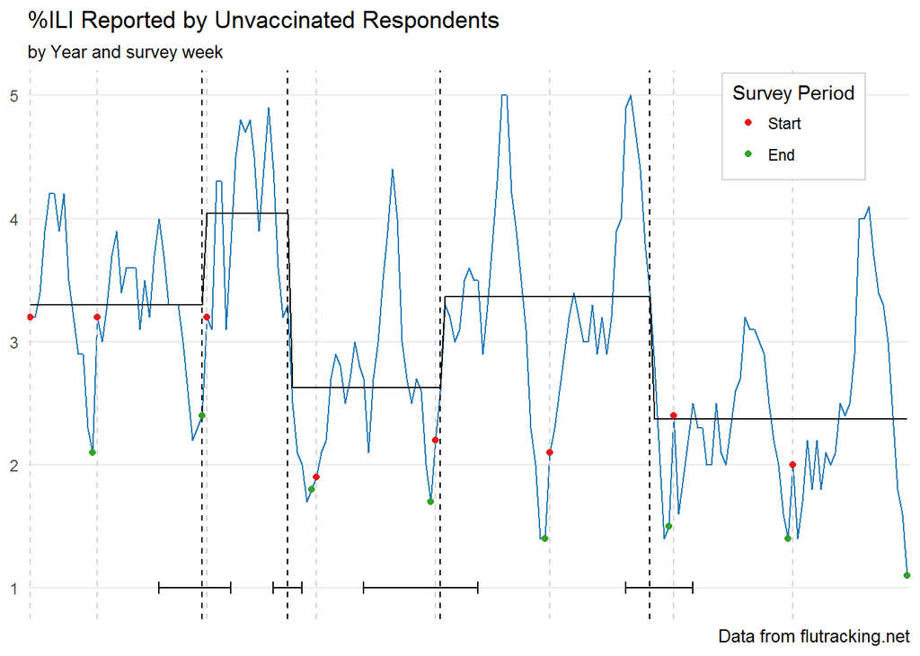

Here is the same data faceted by Year.

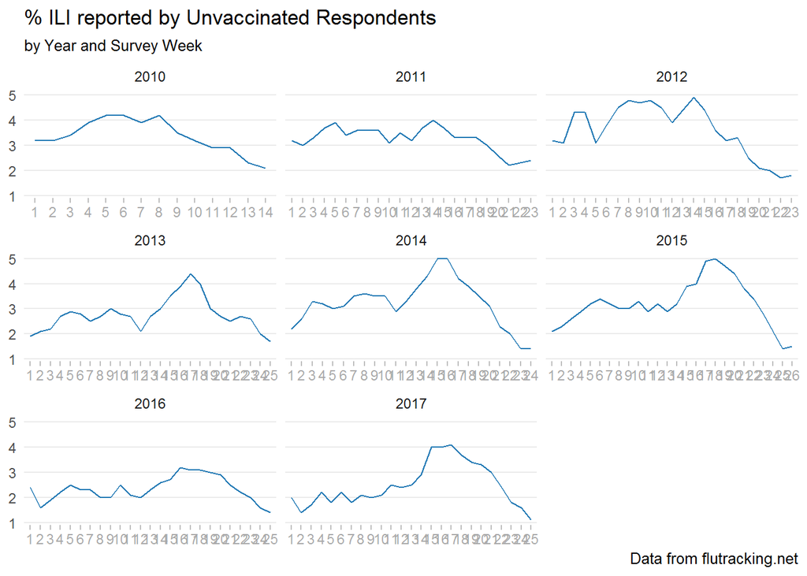